# Analysis of pinger results

Ben Anderson (@dataknut)

28 April 2016

**About this document**

This document was created using knitr in [RStudio](http://www.rstudio.com). Knitr allows the embedding of R code within markdown text documents allowing them to be updated and re-run. Things to note:

- Knitr will display warnings (but not errors) from R. The warnings may or may not be significant.
- Knitr is very clever but it does not always support pretty tables.

This code processes and anlayses the results of running https://github.com/dataknut/ping-log/blob/master/pinger.py which is a .csv file with the form:

```
timestamp,host,milliseconds
2016-04-28 10:53:56,www.google.co.uk,83.548
2016-04-28 10:53:57,router,121.820
2016-04-28 10:54:07,www.google.co.uk,71.019
2016-04-28 10:54:07,router,9.875
```

# Introduction

Purpose:

- To test connectivity to:
- a home router and
- the wider internet
- in order to attempt to work out where connectivity problems are occuring.

Data:

- .csv files produced by pinger.py

Code:

- this code: https://github.com/dataknut/ping-log/blob/master/pinger_process_results.Rmd

# Basic responses

Throughout the following NA usually means ping failed to return.

The file has 1346 records starting at 2016-04-28 13:23:00 and finishing at 2016-04-28 15:19:06.

How many rows (cases) & variables and how many records for each host?

```
## [1] 1346    4
```

Did we get any errors?

|  | router | www.google.co.uk | NA |
| --- | --- | --- | --- |
| OK | 673 | 673 | 0 |
| NA | 0 | 0 | 0 |

Summary of variables (after converting datetime to R datetime (POSIX))

```
##      host            milliseconds         error
##  Length:1346        Min.   :   6.186   Length:1346
##  Class :character   1st Qu.:  25.249   Class :character
##  Mode  :character   Median :  64.286   Mode  :character
##                     Mean   : 164.471
##                     3rd Qu.: 172.604
##                     Max.   :5215.486
##                     NA's   :1
##    datetime_r
##  Min.   :2016-04-28 13:23:00
##  1st Qu.:2016-04-28 13:51:54
##  Median :2016-04-28 14:21:13
##  Mean   :2016-04-28 14:21:00
##  3rd Qu.:2016-04-28 14:50:04
##  Max.   :2016-04-28 15:19:06
##
```

# Results by host

Distribution of mean ping response times:

```
##                host   N     Mean       sd
## 1: www.google.co.uk 673 201.5589 392.7641
## 2:           router 673 127.4384 305.0892
```

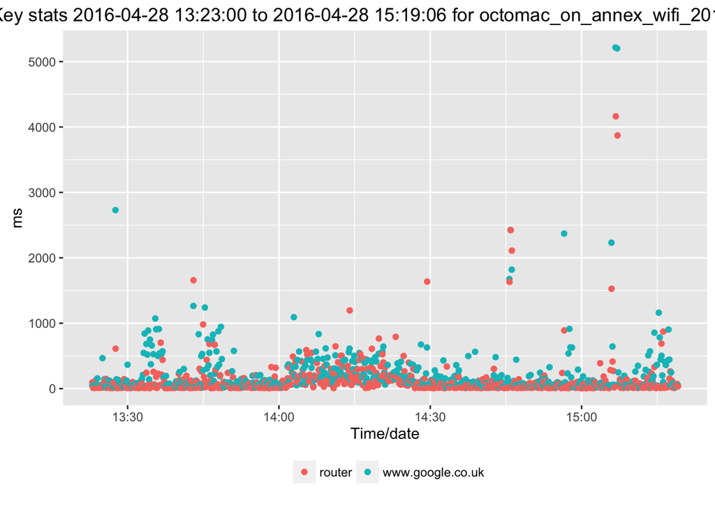

Last run: 2016-04-28 15:19:12

Analysis completed in: 1.7733469 seconds using knitr & [RStudio](http://www.rstudio.com)